# Insurance Claims

### DATA EXPLORATORY ANALYSIS AND HYPOTHESIS TESTING FOR INSURANCE CLAIMS DATA

```python
#Importing Libraries
import pandas as pd
from datetime import datetime as ddt
import matplotlib.pyplot as plt
import scipy.stats as stats
import numpy as np
```

```python
tbl1=pd.read_csv('claims.csv')
tbl2=pd.read_csv('cust_demographics.csv')
```

```python
tbl1.head(2)
```

|  | claim_id | customer_id | incident_cause | claim_date | claim_area | police_report | claim_type | claim_amount | total_policy_claims | fraudulent |
| --- | --- | --- | --- | --- | --- | --- | --- | --- | --- | --- |
| 0 | 54004764 | 21868593 | Driver error | 11/27/2017 | Auto | No | Material only | $2980 | 1.0 | No |
| 1 | 33985796 | 75740424 | Crime | 10/03/2018 | Home | Unknown | Material only | $2980 | 3.0 | No |

```python
tbl2.head(2)
```

|  | CUST_ID | gender | DateOfBirth | State | Contact | Segment |
| --- | --- | --- | --- | --- | --- | --- |
| 0 | 21868593 | Female | 12-Jan-79 | VT | 789-916-8172 | Platinum |
| 1 | 75740424 | Female | 13-Jan-70 | ME | 265-543-1264 | Silver |

```python
data=pd.merge(tbl1,tbl2,left_on='customer_id',right_on='CUST_ID',how='inner')
```

```python
data.head(2)
```

|  | claim_id | customer_id | incident_cause | claim_date | claim_area | police_report | claim_type | claim_amount | total_policy_claims | fraudulent | CUST_ID | gender | DateOfBirth | State | Contact | Segment |
| --- | --- | --- | --- | --- | --- | --- | --- | --- | --- | --- | --- | --- | --- | --- | --- | --- |
| 0 | 54004764 | 21868593 | Driver error | 11/27/2017 | Auto | No | Material only | $2980 | 1.0 | No | 21868593 | Female | 12-Jan-79 | VT | 789-916-8172 | Platinum |
| 1 | 33985796 | 75740424 | Crime | 10/03/2018 | Home | Unknown | Material only | $2980 | 3.0 | No | 75740424 | Female | 13-Jan-70 | ME | 265-543-1264 | Silver |

##### Performing a data audit for the datatypes and find out if there are any mismatch within the current datatypes of the columns and their business significance.

```python
data.info()
```

```
<class 'pandas.core.frame.DataFrame'>
Int64Index: 1085 entries, 0 to 1084
Data columns (total 16 columns):
 #   Column               Non-Null Count  Dtype
---  ------               --------------  -----
 0   claim_id             1085 non-null   int64
 1   customer_id          1085 non-null   int64
 2   incident_cause       1085 non-null   object
 3   claim_date           1085 non-null   object
 4   claim_area           1085 non-null   object
 5   police_report        1085 non-null   object
 6   claim_type           1085 non-null   object
 7   claim_amount         1020 non-null   object
 8   total_policy_claims  1075 non-null   float64
 9   fraudulent           1085 non-null   object
 10  CUST_ID              1085 non-null   int64
 11  gender               1085 non-null   object
 12  DateOfBirth          1085 non-null   object
 13  State                1085 non-null   object
 14  Contact              1085 non-null   object
 15  Segment              1085 non-null   object
dtypes: float64(1), int64(3), object(12)
memory usage: 144.1+ KB
```

```python
data.claim_date=pd.to_datetime(data.claim_date,format='%m/%d/%Y')
```

```python
data.DateOfBirth=pd.to_datetime(data.DateOfBirth,format='%d-%b-%y')
```

```python
data.DateOfBirth=np.where(data.DateOfBirth.dt.year>=2020,data.DateOfBirth+pd.DateOffset(years=-100),data.DateOfBirth)
```

```python
data.drop(columns=['Contact','CUST_ID'],inplace=True)
```

```python
data.total_policy_claims=data.total_policy_claims.astype('object')
```

```python
data.head(2)
```

|  | claim_id | customer_id | incident_cause | claim_date | claim_area | police_report | claim_type | claim_amount | total_policy_claims | fraudulent | gender | DateOfBirth | State | Segment |
| --- | --- | --- | --- | --- | --- | --- | --- | --- | --- | --- | --- | --- | --- | --- |
| 0 | 54004764 | 21868593 | Driver error | 2017-11-27 | Auto | No | Material only | $2980 | 1 | No | Female | 1979-01-12 | VT | Platinum |
| 1 | 33985796 | 75740424 | Crime | 2018-10-03 | Home | Unknown | Material only | $2980 | 3 | No | Female | 1970-01-13 | ME | Silver |

#### Converting the column claim_amount to numeric. Using the appropriate modules/attributes to remove the currancy sign.

```python
data.claim_amount=data.claim_amount.str.strip('$').astype('float64')
```

##### Of all the injury claims, some of them have gone unreported with thepolice. Creating an alert flag (1,0) for all such claims.

```python
data['injury_claim']=np.where((data.claim_type.isin(['Injury only','Material and injury']))&(data.police_report!='Yes'),1,0)
```

##### One customer can claim for insurance more than once and in each claim, multiple categories of claims can be involved. However, customer ID should remain unique.

##### Retain the most recent observation and delete any duplicated records in the data based on the customer ID column.

```python
data.sort_values(by='claim_date',ascending=False).drop_duplicates(subset='customer_id',keep='first')
```

|  | claim_id | customer_id | incident_cause | claim_date | claim_area | police_report | claim_type | claim_amount | total_policy_claims | fraudulent | gender | DateOfBirth | State | Segment | injury_claim |
| --- | --- | --- | --- | --- | --- | --- | --- | --- | --- | --- | --- | --- | --- | --- | --- |
| 286 | 99775483 | 93915431 | Other causes | 2018-10-30 | Auto | No | Material and injury | 42124.5 | 1 | Yes | Male | 1967-09-08 | ME | Gold | 1 |
| 354 | 98795403 | 38011078 | Crime | 2018-10-30 | Auto | Unknown | Material only | 1940.0 | 1 | No | Female | 1976-05-20 | NE | Gold | 0 |
| 1055 | 43042986 | 58451506 | Natural causes | 2018-10-30 | Auto | No | Material only | 2420.0 | 1 | No | Male | 1968-04-22 | FL | Gold | 0 |
| 941 | 74761374 | 46710738 | Driver error | 2018-10-30 | Auto | No | Material only | 1830.0 | 1 | No | Male | 1977-04-28 | MO | Gold | 0 |
| 322 | 87329176 | 77510822 | Other driver error | 2018-10-30 | Auto | Unknown | Material only | NaN | 2 | No | Female | 1986-03-18 | AK | Silver | 0 |
| ... | ... | ... | ... | ... | ... | ... | ... | ... | ... | ... | ... | ... | ... | ... | ... |
| 231 | 61374372 | 77219712 | Other causes | 2017-01-01 | Auto | No | Material and injury | 20200.0 | 1 | No | Female | 1999-08-05 | NH | Platinum | 1 |
| 905 | 42280334 | 42664554 | Other causes | 2017-01-01 | Auto | No | Injury only | 27670.0 | 1 | No | Female | 1993-08-13 | TN | Gold | 1 |
| 195 | 23636125 | 64840478 | Other driver error | 2017-01-01 | Auto | Unknown | Material and injury | 17290.0 | 1 | No | Female | 1974-02-14 | NM | Silver | 1 |
| 177 | 25647821 | 74155265 | Natural causes | 2017-01-01 | Auto | No | Material only | 2080.0 | 1 | No | Male | 1985-11-16 | TX | Gold | 0 |
| 181 | 90591192 | 61745840 | Other driver error | 2017-01-01 | Home | No | Material and injury | 30930.0 | 1 | No | Female | 1994-07-24 | MA | Platinum | 1 |

1078 rows × 15 columns

#### Checking for missing values and impute the missing values with an appropriate value. (mean for continuous and mode for categorical)

```python
data.isna().sum()
```

```
claim_id                0
customer_id             0
incident_cause          0
claim_date              0
claim_area              0
police_report           0
claim_type              0
claim_amount           65
total_policy_claims    10
fraudulent              0
gender                  0
DateOfBirth             0
State                   0
Segment                 0
injury_claim            0
dtype: int64
```

```python
data.claim_amount.fillna(data.claim_amount.mean(),inplace=True)
```

```python
data.total_policy_claims.fillna(data.total_policy_claims.mode()[0],inplace=True)
```

#### Calculating the age of customers in years. Based on the age, categorizing the customers according to the below criteria

Children < 18

Youth 18-30

Adult 30-60

Senior > 60

```python
age=ddt.now()-data.DateOfBirth
data['age']=round(age.dt.days/365.25)
```

```python
data['age_grp']=np.where(data.age<18,"Children",np.where((data.age>=18)&(data.age<30),"Youth",np.where((data.age>=30)&(data.age<60),"Adult",'Senior')))
```

```python
data.head(10)
```

|  | claim_id | customer_id | incident_cause | claim_date | claim_area | police_report | claim_type | claim_amount | total_policy_claims | fraudulent | gender | DateOfBirth | State | Segment | injury_claim | age | age_grp |
| --- | --- | --- | --- | --- | --- | --- | --- | --- | --- | --- | --- | --- | --- | --- | --- | --- | --- |
| 0 | 54004764 | 21868593 | Driver error | 2017-11-27 | Auto | No | Material only | 2980.0 | 1.0 | No | Female | 1979-01-12 | VT | Platinum | 0 | 42.0 | Adult |
| 1 | 33985796 | 75740424 | Crime | 2018-10-03 | Home | Unknown | Material only | 2980.0 | 3.0 | No | Female | 1970-01-13 | ME | Silver | 0 | 51.0 | Adult |
| 2 | 53522022 | 30308357 | Other driver error | 2018-02-02 | Auto | No | Material only | 3369.5 | 1.0 | Yes | Female | 1984-03-11 | TN | Silver | 0 | 37.0 | Adult |
| 3 | 63017412 | 30308357 | Driver error | 2018-04-04 | Auto | No | Material only | 1950.0 | 6.0 | No | Female | 1984-03-11 | TN | Silver | 0 | 37.0 | Adult |
| 4 | 13015401 | 47830476 | Natural causes | 2018-06-17 | Auto | No | Material only | 1680.0 | 1.0 | No | Female | 1986-05-01 | MA | Silver | 0 | 35.0 | Adult |
| 5 | 91609100 | 47830476 | Natural causes | 2017-04-12 | Auto | Unknown | Material only | 1440.0 | 1.0 | No | Female | 1986-05-01 | MA | Silver | 0 | 35.0 | Adult |
| 6 | 22890252 | 19269962 | Crime | 2018-01-13 | Auto | No | Material only | 2680.0 | 1.0 | No | Male | 1977-05-13 | NV | Gold | 0 | 44.0 | Adult |
| 7 | 39219616 | 19269962 | Other causes | 2018-09-26 | Auto | No | Material only | 2240.0 | 2.0 | No | Male | 1977-05-13 | NV | Gold | 0 | 44.0 | Adult |
| 8 | 24050443 | 21831191 | Other driver error | 2017-10-04 | Auto | No | Injury only | 38306.5 | 3.0 | Yes | Male | 1977-05-17 | NH | Gold | 1 | 44.0 | Adult |
| 9 | 91475471 | 21831191 | Driver error | 2018-02-09 | Auto | Unknown | Material and injury | 36810.0 | 1.0 | No | Male | 1977-05-17 | NH | Gold | 1 | 44.0 | Adult |

##### Average amount claimed by the customers from various segments

```python
data.groupby(by='Segment').claim_amount.mean()
```

```
Segment
Gold        12829.631974
Platinum    12341.952267
Silver      12208.435570
Name: claim_amount, dtype: float64
```

```python
crit_date=ddt.strptime('1 October,2018','%d %B,%Y')
crit_date=crit_date+pd.DateOffset(days=-20)
data[data.claim_date<crit_date].claim_amount.sum()
```

```
12402276.019607846
```

##### No of Total adults from TX, DE and AK who claimed insurance for driver related issues and causes.

```python
data[(data.age_grp=='Adult')&(data.State.isin(['TX','DE','AK']))&
     (data.incident_cause.isin(['Driver error','Other driver error']))].age_grp.count()
```

```
28
```

##### Claim Amount(Gender)

```python
data['Segment_Gender']=data.Segment+'  ('+data.gender+')'
```

```python
Q11=data.groupby(by='Segment_Gender').claim_amount.sum()
```

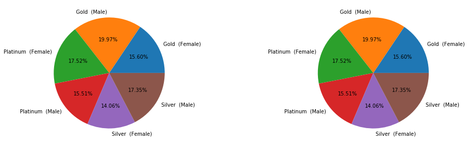

```python
fig,ax=plt.subplots(1,2)
fig.set_size_inches(17,5)
#pct format method 1
ax[0].pie(Q11,labels=Q11.index,autopct = lambda p:f'{p:.2f}%')
#pct format method 2
ax[1].pie(Q11,labels=Q11.index,autopct = '%.2f%%')
plt.show()
```

##### Among males and females, which gender had claimed the most for any type of driver related issues

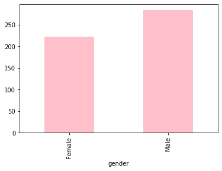

```python
data[data.incident_cause.isin(['Driver error','Other driver error'])].groupby(by='gender').gender.count().plot(kind='bar',color='pink')
plt.show()
```

##### Which age group had the maximum fraudulent policy claims

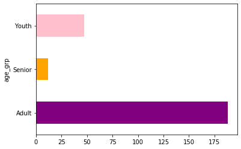

```python
pd.crosstab(data.age_grp,data.fraudulent).iloc[:,1].plot(kind='barh',color=['purple','orange','pink'])
plt.show()
```

##### Monthly trend of the total amount that has been claimed by the customers.

```python
data['Month_name']=data.claim_date.dt.month_name()
data['Month']=data.claim_date.dt.month
```

```python
Q14=pd.DataFrame(data.groupby(by=['Month_name','Month']).claim_amount.sum()).reset_index()
```

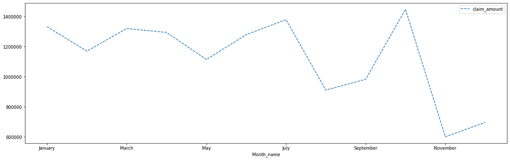

```python
Q14.sort_values(by='Month').plot(x='Month_name',y='claim_amount',figsize=(20,6),linestyle='--')
plt.show()
```

##### Average claim amount for gender and age categories(For Fraudulent and Non Fraudulent)

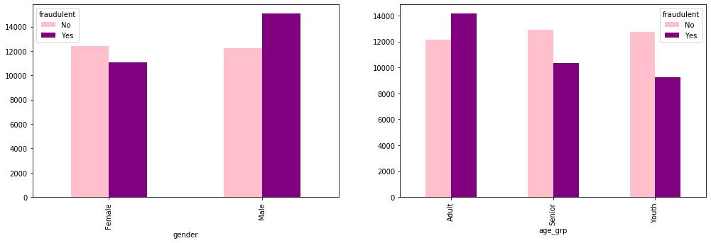

```python
fig,axis=plt.subplots(1,2)
fig.set_size_inches(17,5)
data.pivot_table(values='claim_amount',index='gender',columns='fraudulent',aggfunc='mean').plot(kind='bar',ax=axis[0],color=['pink','purple'])
data.pivot_table(values='claim_amount',index='age_grp',columns='fraudulent',aggfunc='mean').plot(kind='bar',ax=axis[1],color=['pink','purple'])
plt.show()
```

# Hypothesis Testing

##### Is there any similarity in the amount claimed by males and females?

```python
data_male=data[data.gender=="Male"].copy()
data_female=data[data.gender=="Female"].copy()
```

```python
print( 'mean of male: ', data_male.claim_amount.mean(), ' | spend of female: ', data_female.claim_amount.mean() )
```

```
mean of male:  12853.058506136278  | spend of female:  12062.634706623674
```

```python
# H0: Amount claimed by males is same as amount claimed by females
# H1: Amount claimed by males and females are significantly different

# CI:95%  , pvalue=0.05  (alpha region cutoff value)

tstat,pvalue=stats.ttest_ind(data_male.claim_amount,data_female.claim_amount)

print('t statsitc value is : ',tstat ,'\t  p value is : ',pvalue)

if pvalue>0.05:
    print('We fail to reject the H0 ')
else:
    print('We reject the H0 ')
```

```
t statsitc value is :  0.9738138415066818 	  p value is :  0.33036643165116597
We fail to reject the H0
```

```python
# Therefore Amount claimed is not gender biased
```

##### Is there any relationship between age category and segment?

```python
Q17=pd.crosstab(data.age_grp,data.Segment)
```

```python
# H0: Age category and Segment are not related to eachother
# H1: Age category and Segment are dependent on  eachother

# CI:95%  , pvalue=0.05  (alpha region cutoff value)

chi_value,pvalue,df,expect_fre=stats.chi2_contingency(Q17)

print('\n chi2 value is :',chi_value,'\n p value is : ',pvalue,'\n Degree of Freedom is : ',df,'\n Expected Frequency Table is : \n',expect_fre,'\n \n')

if pvalue>0.05:
    print('We fail to reject the H0 ')
else:
    print('We reject the H0 ')
```

```
 chi2 value is : 1.492885143550476
 p value is :  0.8279010231973141
 Degree of Freedom is :  4
 Expected Frequency Table is :
 [[277.88018433 268.24700461 257.87281106]
 [ 16.24423963  15.68110599  15.07465438]
 [ 80.87557604  78.0718894   75.05253456]]


We fail to reject the H0
```

```python
# Insurance Segments are not associated with Ages of people.
```

##### The current year has shown a significant rise in claim amounts as compared to 2016-17 fiscal average which was 10,000.

```python
# Assuming the current year is 2018 and fiscal year starts from jan 1st.
Q18=data.loc[data.claim_date.dt.year==2018,'claim_amount']
```

```python
# H0: Amount claimed during 2016-2017 is sames as amount claimed from 2018- today| u ==10,000
# H1: Amount claimed during 2016-2017 and amount claimed from 2018- today are significantly different.| u<>10,000

# CI:95%  , pvalue=0.05  (alpha region cutoff value), or z value ~ 1.6

tstat,pvalue=stats.ttest_1samp(Q18,10000)

print('t statsitc value is : ',tstat ,'\t  p value is : ',pvalue,'\t df is : ',Q18.shape[0]-1)

if pvalue>0.05:
    print('We fail to reject the H0 ')
else:
    print('We reject the H0 ')
```

```
t statsitc value is :  4.421788475402985 	  p value is :  1.2086880225728461e-05 	 df is :  486
We reject the H0
```

```python
#Therefore Amount claimed during 2016-2017 and amount claimed from 2018- today are significantly different.
```

```python
#pvalue/2=6.0434401128642305e-06 which is still less than 0.05
#since df>100 therefore t value of 4.42 lies at the right alpha region.
#Therefore it can be concluded that number of accidents have been increased current year and hence a significant rise in claim amounts.
```

##### Is there any difference between age groups and insurance claims?

```python
s1=data.loc[data.age_grp=="Adult",'claim_amount']
s2=data.loc[data.age_grp=="Youth",'claim_amount']
s3=data.loc[data.age_grp=="Senior",'claim_amount']
```

```python
# Ho: Claims are not different from each other | m1 = m2 = m3
# Ha: Claims are different

# CI: 95%, p: 0.05


fstats,pvalue=stats.f_oneway( s1, s2, s3 )
print('F statsitc value is : ',fstats ,'\t  p value is : ',pvalue)

if pvalue>0.05:
    print('We fail to reject the H0 ')
else:
    print('We reject the H0 ')
```

```
F statsitc value is :  0.15906201559971847 	  p value is :  0.8529634024814718
We fail to reject the H0
```

```python
#Therfore all age groups has claimed almost same amount of insurance claims.
```

##### Is there any relationship between total number of policy claims and the claimed amount?

```python
#Method 1

# Ho: No corelation
# Ha: There is a relationship between two continuous variables
# CI: 95%, p: 0.05


spearson,pvalue=stats.pearsonr( data.total_policy_claims, data.claim_amount )
print('Spearsons coefficient  value is : ',spearson ,'\t  p value is : ',pvalue)

if pvalue>0.05:
    print('We fail to reject the H0 ')
else:
    print('We reject the H0 ')
```

```
Spearsons coefficient  value is :  -0.01795295331890298 	  p value is :  0.5547051246400856
We fail to reject the H0
```

```python
#Method 2
data[['total_policy_claims','claim_amount']].corr()
```

|  | total_policy_claims | claim_amount |
| --- | --- | --- |
| total_policy_claims | 1.000000 | -0.017953 |
| claim_amount | -0.017953 | 1.000000 |

```python
# That is very weak correlation
```